# Coursera Data Analysis

Eirlys Vo

2024-08-30

## Objective

The goal of this project is to perform a comprehensive analysis of a data set related to Coursera courses. I explored the dataset to understand the data structure and performed necessary data cleansing. Then, I created visualizations to see insights for online studying trends and user engagement.

## Data Collection

The data is provided on Kaggle, which can be viewed [here.](https://www.kaggle.com/datasets/elvinrustam/coursera-dataset)

There are two data sets which are cleaned and uncleaned. For this project, I will only use the uncleaned version since our aim includes data cleansing. The dataset includes various columns which are basic information about a course. I will use `URL` link as our main unique index, which I will also clean on this in the **Project Workflow** section.

Further data set description can be read [here.](https://www.kaggle.com/datasets/elvinrustam/coursera-dataset)

```r
orig_df <- read.csv("CourseraDataset-Unclean.csv")
summary(orig_df)
```

```
##  Course.Title           Rating         Level             Duration
##  Length:9595        Min.   :1.500   Length:9595        Length:9595
##  Class :character   1st Qu.:4.600   Class :character   Class :character
##  Mode  :character   Median :4.700   Mode  :character   Mode  :character
##                     Mean   :4.652
##                     3rd Qu.:4.800
##                     Max.   :5.000
##                     NA's   :1439
##    Schedule            Review          What.you.will.learn  Skill.gain
##  Length:9595        Length:9595        Length:9595         Length:9595
##  Class :character   Class :character   Class :character    Class :character
##  Mode  :character   Mode  :character   Mode  :character    Mode  :character
##
##
##
##
##    Modules           Instructor         Offered.By          Keyword
##  Length:9595        Length:9595        Length:9595        Length:9595
##  Class :character   Class :character   Class :character   Class :character
##  Mode  :character   Mode  :character   Mode  :character   Mode  :character
##
##
##
##
##   Course.Url
##  Length:9595
##  Class :character
##  Mode  :character
##
##
##
##
```

```r
colnames(orig_df)
```

```
##  [1] "Course.Title"        "Rating"              "Level"
##  [4] "Duration"            "Schedule"            "Review"
##  [7] "What.you.will.learn" "Skill.gain"          "Modules"
## [10] "Instructor"          "Offered.By"          "Keyword"
## [13] "Course.Url"
```

## Libraries and Tools

We will set up necessary libraries that can help me clean and visualize data in further steps:

```r
library(tidyverse)
library(zoo)
library(textcat)
library(reshape2)
```

## Project Workflow

### 1. Set columns name

The dataset has some columns’ names which we find them hard to use throughout the workflow. Therefore, we would rather change them into easily accessible names. We will use the `rename` function to apply new columns’ names:

```r
orig_df <- rename(orig_df, crs_title = "Course.Title")
orig_df <- rename(orig_df, will_learn = "What.you.will.learn")
orig_df <- rename(orig_df, offered = "Offered.By")
orig_df <- rename(orig_df, URL = "Course.Url")
orig_df <- rename(orig_df, skill = "Skill.gain")

data_types <- sapply(orig_df, typeof)
results <- paste(names(orig_df), ":", data_types, collapse = ", ")
cat(results,'\n')
```

```
## crs_title : character, Rating : double, Level : character, Duration : character, Schedule : character, Review : character, will_learn : character, skill : character, Modules : character, Instructor : character, offered : character, Keyword : character, URL : character
```

We want to use function `head()` to see the format of data in every column:

```r
head(orig_df)
```

```
##                                                      crs_title Rating
## 1                                            Fashion as Design    4.8
## 2                                       Modern American Poetry    4.4
## 3                                    Pixel Art for Video Games    4.5
## 4              Distribución digital de la música independiente     NA
## 5 The Blues: Understanding and Performing an American Art Form    4.8
## 6                                 So You Think You Know Tango?    4.6
##            Level                     Duration          Schedule        Review
## 1 Beginner level     20 hours (approximately) Flexible schedule 2,813 reviews
## 2 Beginner level Approx. 34 hours to complete Flexible schedule   100 reviews
## 3 Beginner level      9 hours (approximately) Flexible schedule   227 reviews
## 4 Beginner level  Approx. 8 hours to complete Flexible schedule
## 5 Beginner level Approx. 11 hours to complete Flexible schedule   582 reviews
## 6 Beginner level  Approx. 5 hours to complete Flexible schedule   107 reviews
##                                                                                                                                                                                                                                                                 will_learn
```

[output cut: 41 more lines]

### 2. Cleansing N/A values for Rating col

In cleansing process, we first want to see the amount of N/A values in every column:

```r
colSums(is.na(orig_df))
```

```
##  crs_title     Rating      Level   Duration   Schedule     Review will_learn
##          0       1439          0          0          0          0          0
##      skill    Modules Instructor    offered    Keyword        URL
##          0          0          0          0          0          0
```

There are about 1500 `N/A` values for column `Rating`. The `Rating` column has format of `double` so to be easy, we can fill `N/A` with 0.

In case we need to clean any sudden `N/A` in the future (if having additional column), it would be better to create a custom function to help us handle this. The function will need inputs of a data frame, column’s name need to be cleansed, and the replaced value for it.

We use `mutate()` to easily access the data frame and its columns. Then, we use `sym()` function to converts the column name from a string to a symbol since our input `colname` of the function is a string and `mutate()` can’t handle string. We need `!!` before it to unquote the `sym()` function.

Then, we have the `ifelse` to check a value is `N/A`:

```r
clean_NA_func <- function(input_df, colname, replace_value) {
  input_df <- input_df %>% mutate(
    !!sym(colname) := ifelse(
      is.na(!!sym(colname)), replace_value, !!sym(colname)
    )
  )
  return(input_df)
}
```

We now apply this function to clean the `Rating` column and check again:

```r
orig_df <- clean_NA_func(orig_df, "Rating", 0)
colSums(is.na(orig_df))
```

```
##  crs_title     Rating      Level   Duration   Schedule     Review will_learn
##          0          0          0          0          0          0          0
##      skill    Modules Instructor    offered    Keyword        URL
##          0          0          0          0          0          0
```

### 3. Cleansing empty values for Level column

There are some entries that are not identified as `N/A` but empty. We want to build a function that helps fill those empty entries with desired values. The logic behind this function is similar to the `clean_NA_func`, but we replace the condition checking `is.na` with `== ""`.

```r
colSums(orig_df == "")
```

```
##  crs_title     Rating      Level   Duration   Schedule     Review will_learn
##          0          0       1265        262        683       1443       4611
##      skill    Modules Instructor    offered    Keyword        URL
##          0          0          0          0          0          0
```

```r
clean_empty_func <- function(input_df, colname, replace_value) {
  input_df <- input_df %>% mutate(
    !!sym(colname) := ifelse(
      !!sym(colname) == "", replace_value, !!sym(colname)
    )
  )
}
```

There are number of columns with empty entries. Depending on each column data structure, we fill the empty with different values.

```r
columns_to_clean = c('Level','Duration','Schedule','will_learn','skill','Modules','Instructor')

for (col in columns_to_clean) {
  orig_df <- clean_empty_func(orig_df, col, 'No information')
}

colSums(orig_df=="")
```

```
##  crs_title     Rating      Level   Duration   Schedule     Review will_learn
##          0          0          0          0          0       1443          0
##      skill    Modules Instructor    offered    Keyword        URL
##          0          0          0          0          0          0
```

For `Review` column specifically, since there is `reviews` in the entries, we will remove this word (using `str_replace_all`), fill the empty ones with 0, and then convert the data back to `double` type for further analysis purpose.

```r
orig_df$Review <- str_replace_all(orig_df$Review, fixed(" reviews"), "")
orig_df <- clean_empty_func(orig_df, 'Review', '0')
orig_df$Review <- as.double(orig_df$Review)
```

### 4. Cleaning duplicated URL link

```r
sum(duplicated(orig_df$URL))
```

```
## [1] 3191
```

```r
clean_dup_func <- function(input_df, col_dup, col_append) {
  while (sum(duplicated(input_df[, col_dup])) >= 1) {

    dup_df <- input_df[which(duplicated(input_df[, col_dup])), ] # get df of duplicated rows of URL
    link_1st_row <- as.character(dup_df[1, col_dup])
    row_indices <- as.numeric(which(input_df[, col_dup] == link_1st_row)) # get rows having same links
    row_indices_without_min <- row_indices[-which.min(row_indices)]

    for (i in row_indices_without_min) {
      input_df[min(row_indices), col_append] <- paste(
        input_df[min(row_indices), col_append], input_df[i, col_append],
        sep = ", "
      )
    }

    input_df <- input_df[-row_indices_without_min, ]

  }

  return(input_df)
}

orig_df <- clean_dup_func(orig_df, "URL", "Keyword")
summary(orig_df)
```

```
##   crs_title             Rating         Level             Duration
##  Length:6404        Min.   :0.000   Length:6404        Length:6404
##  Class :character   1st Qu.:4.300   Class :character   Class :character
##  Mode  :character   Median :4.600   Mode  :character   Mode  :character
##                     Mean   :3.739
##                     3rd Qu.:4.800
##                     Max.   :5.000
##
##    Schedule             Review       will_learn           skill
##  Length:6404        Min.   :  0.0   Length:6404        Length:6404
##  Class :character   1st Qu.: 10.0   Class :character   Class :character
##  Mode  :character   Median : 59.0   Mode  :character   Mode  :character
##                     Mean   :168.8
##                     3rd Qu.:244.0
##                     Max.   :998.0
##                     NA's   :1173
##    Modules           Instructor          offered            Keyword
##  Length:6404        Length:6404        Length:6404        Length:6404
##  Class :character   Class :character   Class :character   Class :character
##  Mode  :character   Mode  :character   Mode  :character   Mode  :character
##
##
##
##
##      URL
##  Length:6404
##  Class :character
##  Mode  :character
##
##
##
##
```

### 5. Cleaning *Social Sciences* duplication in Keyword column

After we perform the fourth cleaning, there seems to be duplicated `Social Sciences` keyword and we don’t want that. At this step, we don’t build a custom function here. Instead, we directly replace any row having more than 1 `Social Sciences` keyword with single term. We perform that with functions `str_count` for counting purpose and `str_replace_all` for replacing purpose.

```r
orig_df$Keyword <- ifelse(
  str_count(orig_df$Keyword, fixed("Social Sciences")) > 1, str_replace_all(
    orig_df$Keyword, fixed("Social Sciences, Social Sciences"), "Social Sciences"
  ), orig_df$Keyword
)

unique(
  (orig_df %>% mutate(
    count_ss = str_count(orig_df$Keyword, fixed("Social Sciences"))
  )
  )$count_ss
)
```

```
## [1] 0 1
```

After performing replacement, we can see that now every row only has 0 or 1 keyword `Social Sciences` and this is desirable.

### 6. Cleaning specific signs *[,],’*

When viewing the data set, there are columns skill, Modules, Instructor, offered having specific signs in their values. We want to get rid of these for consistent data purpose. Since there are different signs, we want to build a custom function for different inputs purpose. The logic behind this custom function is similar to the others created above, but we have placeholder for `sign2` and `sign3` inputs since we are not sure how many signs we will have and use function `gsub` for matching and replacement.

```r
head(orig_df)
```

```
##                                                      crs_title Rating
## 1                                            Fashion as Design    4.8
## 2                                       Modern American Poetry    4.4
## 3                                    Pixel Art for Video Games    4.5
## 4              Distribución digital de la música independiente    0.0
## 5 The Blues: Understanding and Performing an American Art Form    4.8
## 6                                 So You Think You Know Tango?    4.6
##            Level                     Duration          Schedule Review
## 1 Beginner level     20 hours (approximately) Flexible schedule     NA
## 2 Beginner level Approx. 34 hours to complete Flexible schedule    100
## 3 Beginner level      9 hours (approximately) Flexible schedule    227
## 4 Beginner level  Approx. 8 hours to complete Flexible schedule      0
## 5 Beginner level Approx. 11 hours to complete Flexible schedule    582
## 6 Beginner level  Approx. 5 hours to complete Flexible schedule    107
##                                                                                                                                                                                                                                                                 will_learn
```

[output cut: 41 more lines]

```r
clean_sign_func <- function(input_df, colname, sign1, sign2 = "", sign3 = "") {
  input_df[, colname] <- sapply(input_df[, colname], function(x) {
    x <- gsub(paste0(fixed(sign1), "|", fixed(sign2), "|", fixed(sign3)), "", x)
  })
  return(input_df)
}

# Apply function
orig_df <- clean_sign_func(orig_df, "skill", "\\[", "\\]", "'")
orig_df <- clean_sign_func(orig_df, "Modules", "\\[", "\\]", "'")
orig_df <- clean_sign_func(orig_df, "Instructor", "\\[", "\\]", "'")
orig_df <- clean_sign_func(orig_df, "offered", "\\[", "\\]", "'")
```

After removing signs, there are empty entries so we will use `clean_empty_func`:

### 7. Cleaning *Duration* column

Having a look at `Duration` column, we see there is inconsistency how data is structure. Therefore, we will change these into single unit `hour`.

```r
orig_df %>% head(20) %>% select(Duration)
```

```
##                        Duration
## 1      20 hours (approximately)
## 2  Approx. 34 hours to complete
## 3       9 hours (approximately)
## 4   Approx. 8 hours to complete
## 5  Approx. 11 hours to complete
## 6   Approx. 5 hours to complete
## 7  Approx. 13 hours to complete
## 8  Approx. 23 hours to complete
## 9   Approx. 5 hours to complete
## 10 Approx. 44 hours to complete
## 11     10 hours (approximately)
## 12 Approx. 26 hours to complete
## 13 Approx. 12 hours to complete
## 14     10 hours (approximately)
## 15 Approx. 21 hours to complete
## 16      6 hours (approximately)
## 17               No information
## 18 Approx. 11 hours to complete
## 19 Approx. 21 hours to complete
## 20 Approx. 17 hours to complete
```

Have a look at unique values for `Duration`:

```r
unique(orig_df$Duration) %>% head(10)
```

```
##  [1] "20 hours (approximately)"     "Approx. 34 hours to complete"
##  [3] "9 hours (approximately)"      "Approx. 8 hours to complete"
##  [5] "Approx. 11 hours to complete" "Approx. 5 hours to complete"
##  [7] "Approx. 13 hours to complete" "Approx. 23 hours to complete"
##  [9] "Approx. 44 hours to complete" "10 hours (approximately)"
```

We can see that there are empty ones, `approx` or `approximately`, `hours`, `minutes`, `week`, and `month`. There is one entry with a full sentence, which is the longest entry. There is entry with `one hour` which does not use digit but letters. Steps to clean include:

- Replace the longest one with a correct one with function `which.max`
- Replace the letters but not digit with a correct one with `which` to find the row index
- Delete `approximate` using `pprox` as regular expression

First, we get entries having `pprox` into a new data frame:

```r
approx_rows <- orig_df[which(str_detect(orig_df$Duration, "pprox")), c("Duration", "URL")]
approx_rows[which.max(nchar(approx_rows$Duration)), "Duration"] <- "2"
unique(approx_rows) %>% head(20)
```

```
##                        Duration
## 1      20 hours (approximately)
## 2  Approx. 34 hours to complete
## 3       9 hours (approximately)
## 4   Approx. 8 hours to complete
## 5  Approx. 11 hours to complete
## 6   Approx. 5 hours to complete
## 7  Approx. 13 hours to complete
## 8  Approx. 23 hours to complete
## 9   Approx. 5 hours to complete
## 10 Approx. 44 hours to complete
## 11     10 hours (approximately)
## 12 Approx. 26 hours to complete
## 13 Approx. 12 hours to complete
## 14     10 hours (approximately)
```

[output cut: 27 more lines]

Since there is only hours estimate, it is easy for us to remove all the characters and add `hours` at the end of these entries.

```r
approx_rows[, "Duration"] <- gsub("[^0-9]", "", approx_rows[, "Duration"])
```

```r
matches <- grepl("pprox", orig_df$Duration)
orig_df[matches, "Duration"] <- approx_rows$Duration
orig_df[which(orig_df$Duration == "one hour"), "Duration"] <- "1"
```

To make sure we don’t have any whitespace during the cleansing process for `Duration` until now, we will trim it:

```r
for (col_name in colnames(orig_df)){
  orig_df[[col_name]] <- trimws(orig_df[[col_name]])
}
```

Take a look at unique values for `Duration` column again, we can see there are amount of entries having similar format `<digits> months at <digits> hours per/a week`. We will build a function to extract the number for months, hours, and minutes. We have 2 parameters: `value` and `request`. The `request` is presented for further purpose of calculating total number of hours for other entries. The two input options for `request` are `total_hours` and `convert_hours`:

```r
duration_func <- function(value, request) {
  if (grepl("^\\d+$", value)) {return(as.numeric(value))}
  else if(value != 'No information'){

    hours <- as.numeric((
      str_extract(value, "(?<=\\b)\\d+(\\.\\d+)?(?=\\s+hours?\\b)")
    ))
    minutes <- as.numeric((
      str_extract(value, "(?<=\\b)\\d+(\\.\\d+)?(?=\\s+min(ute)?s?\\b)")
    ))
    months <- as.numeric((
      str_extract(value, "(?<=\\b)\\d+(\\.\\d+)?(?=\\s+months?\\b)")
    ))

    hours <- ifelse(is.na(hours),0,hours)
    minutes <- ifelse(is.na(minutes),0,minutes)
    months <- ifelse(is.na(months),0,months)

    if (request == 'total_hours') {
      total_hours <- hours + minutes/60 + months*720
      return(round(total_hours,2))
      } else if (request == 'convert_hours') {

        if(months == 0){
        return(hours)

      } else {

        return (hours*months*4)

      }
    } else {
      return (0)
    }
  } else if (value == 'No information') {
    return (0)
    }

  return (value)

}

orig_df <- orig_df %>% mutate(
  Duration = sapply(Duration, duration_func, request = 'convert_hours')
)

orig_df <- orig_df %>% mutate(
  Duration = sapply(Duration, duration_func, request = 'total_hours')
)

orig_df$Duration <- as.double(orig_df$Duration)
```

Have a look at summary of current data set, top 10 rows and bottom 10 rows:

```r
summary(orig_df)
```

```
##   crs_title            Rating             Level              Duration
##  Length:6404        Length:6404        Length:6404        Min.   :  0.00
##  Class :character   Class :character   Class :character   1st Qu.:  7.00
##  Mode  :character   Mode  :character   Mode  :character   Median : 14.00
##                                                           Mean   : 22.96
##                                                           3rd Qu.: 25.00
##                                                           Max.   :480.00
##    Schedule            Review           will_learn           skill
##  Length:6404        Length:6404        Length:6404        Length:6404
##  Class :character   Class :character   Class :character   Class :character
##  Mode  :character   Mode  :character   Mode  :character   Mode  :character
##
##
##
##    Modules           Instructor          offered            Keyword
##  Length:6404        Length:6404        Length:6404        Length:6404
##  Class :character   Class :character   Class :character   Class :character
##  Mode  :character   Mode  :character   Mode  :character   Mode  :character
##
##
##
##      URL
##  Length:6404
##  Class :character
##  Mode  :character
##
##
##
```

```r
orig_df %>% head(10)
```

```
##                                                       crs_title Rating
## 1                                             Fashion as Design    4.8
## 2                                        Modern American Poetry    4.4
## 3                                     Pixel Art for Video Games    4.5
## 4               Distribución digital de la música independiente      0
## 5  The Blues: Understanding and Performing an American Art Form    4.8
## 6                                  So You Think You Know Tango?    4.6
## 7                                    The Politics of Skepticism    4.5
## 8                                  Становлення сучасної України      0
## 9                    Exploring Beethoven's Piano Sonatas Part 4    4.9
## 10                                             悖论：思维的魔方    4.8
##                 Level Duration          Schedule Review
## 1      Beginner level       20 Flexible schedule   <NA>
## 2      Beginner level       34 Flexible schedule    100
## 3      Beginner level        9 Flexible schedule    227
```

[output cut: 73 more lines]

```r
orig_df %>% tail(10)
```

```
##                                                                                      crs_title
## 8686                                                            Felicidad y Políticas Públicas
## 8687                                   Teaching Impacts of Technology: Workplace of the Future
## 8688                                             Teaching Impacts of Technology: Relationships
## 8689                Computational Thinking for K-12 Educators: Abstraction, Methods, and Lists
## 8690                          L’engagement efficace de la société civile dans le développement
## 8691                         Architecting with Google Kubernetes Engine: Production en Español
## 8692 Computational Thinking for K-12 Educators: Nested If Statements and Compound Conditionals
## 8693                                                  Cómo combinar y analizar datos complejos
## 8694             Architecting with Google Kubernetes Engine: Workloads em Português Brasileiro
## 8695                                                        Visualizing static networks with R
##      Rating              Level Duration          Schedule Review
## 8686      0     Beginner level       13 Flexible schedule      0
## 8687      0     Beginner level       12 Flexible schedule      0
## 8688      0     Beginner level       10 Flexible schedule      0
```

[output cut: 73 more lines]

```r
colSums(is.na(orig_df))
```

```
##  crs_title     Rating      Level   Duration   Schedule     Review will_learn
##          0          0          0          0          0       1173          0
##      skill    Modules Instructor    offered    Keyword        URL
##          0          0          0          0          0          0
```

```r
orig_df <- clean_NA_func(orig_df,'Review',0)
```

```r
colSums(orig_df == '')
```

```
##  crs_title     Rating      Level   Duration   Schedule     Review will_learn
##          0          0          0          0          0          0          0
##      skill    Modules Instructor    offered    Keyword        URL
##       2183         95         62          0          0          0
```

```r
for (col in c('skill', 'Modules', 'Instructor')) {
  orig_df <- clean_empty_func(orig_df, col, 'No information')
}
```

## Visualizations

### 1.Number of course vs. Level

We will count the number of courses offered in different levels to see if Coursera is offering centrally to any specific level:

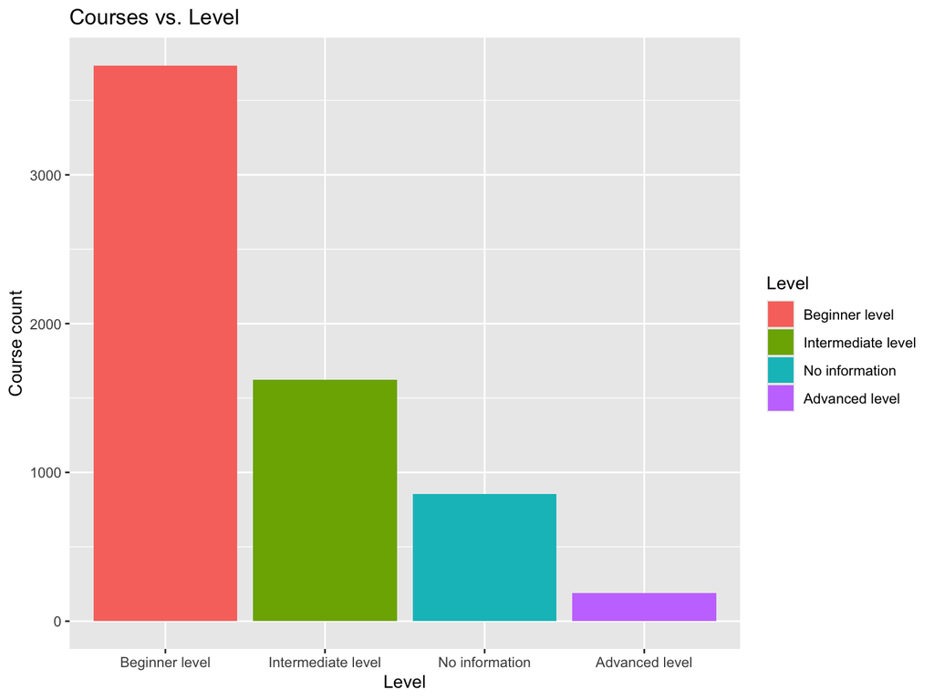

```r
df_count <- orig_df %>% count(Level)
df_count <- df_count %>% mutate(
  Level = reorder(Level, -n)
)

ggplot(df_count, aes(x = Level, y=n, fill = Level)) +
  geom_bar(stat='identity') +
  labs(y = "Course count") +
  ggtitle("Courses vs. Level")
```

The `Beginner` level accounts most courses from Coursera so this platform is a good source for any one in this level.

### 2. Count of offered

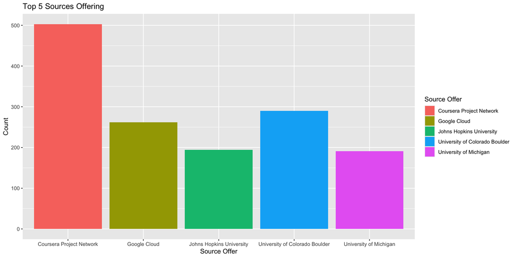

```r
sample <- orig_df %>% count(offered) %>% arrange(desc(n)) %>% head(5)
ggplot(sample, aes(x = offered, y = n, fill = offered)) +
  geom_col() +
  ggtitle('Top 5 Sources Offering') +
  labs(x = 'Source Offer', y = 'Count', fill = 'Source Offer')
```

### 3. Number of Courses vs. Ratings

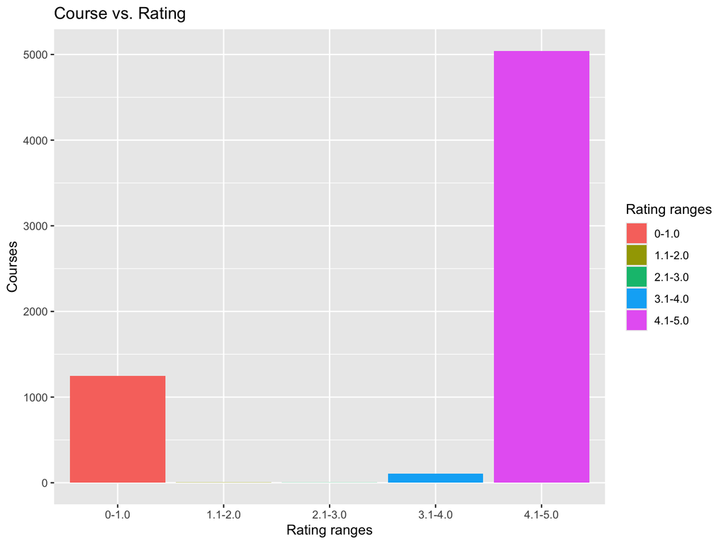

```r
orig_df$Rating <- as.double(orig_df$Rating)
ranges <- c(0, 1.0, 2.0, 3.0, 4.0, 5.1)
orig_df$ranges <- cut(orig_df$Rating, breaks = ranges, labels = c("0-1.0", "1.1-2.0", "2.1-3.0", "3.1-4.0", "4.1-5.0"), right = FALSE)
orig_df[which(is.na(orig_df$Review)), "Review"] <- 0
df_rating <- as.data.frame(count(orig_df, ranges))

ggplot(df_rating, aes(x = ranges, y = n, fill = ranges)) +
  geom_col() +
  labs(x = "Rating ranges", y = "Courses", fill = "Rating ranges") +
  ggtitle("Course vs. Rating")
```

### 4. Average Time Spent for a Course by Level

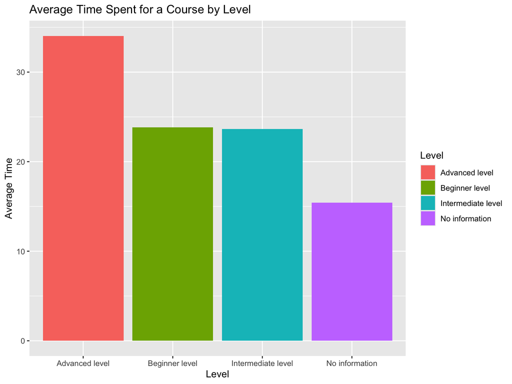

```r
average_time_df <- orig_df %>% group_by(Level) %>%
  summarize(average_time = mean(Duration))
ggplot(average_time_df, aes(x=Level, y=average_time, fill=Level)) +
  geom_col() +
  labs(title='Average Time Spent for a Course by Level', y='Average Time')
```

### 5. Distribution of Courses by Level and Rating Ranges

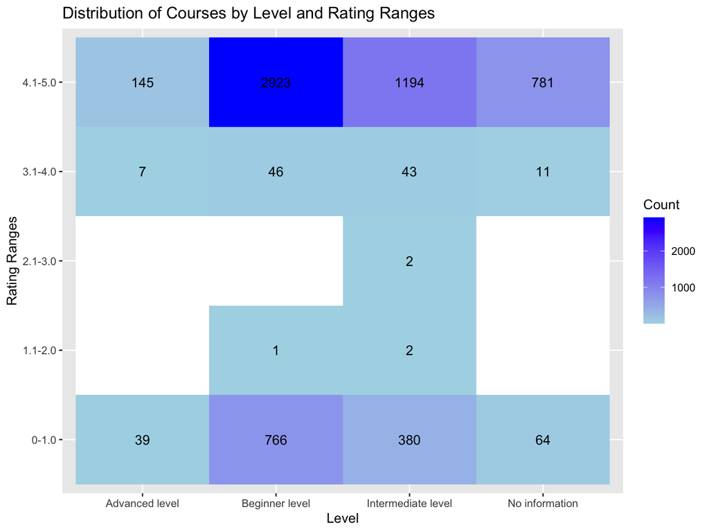

```r
df_count <- orig_df %>% count(Level, ranges)
level_ranges_wideFormat <- dcast(df_count, Level ~ ranges, value.var = 'n')
level_ranges_matrix <- as.matrix(level_ranges_wideFormat[,-1])
rownames(level_ranges_matrix) <- level_ranges_wideFormat$Level
level_ranges_matrix <- melt(level_ranges_matrix, varnames=c("Level","Ranges"), value.name = 'Count')

ggplot(level_ranges_matrix, aes(x=Level, y=Ranges, fill=Count)) +
  geom_tile() +
  geom_text(aes(label=Count), color='black') +
  scale_fill_gradient(low='lightblue', high='blue', na.value='white') +
  labs(y='Rating Ranges', title='Distribution of Courses by Level and Rating Ranges')
```

## Improvements to make

The custom function such as `duration_func` can be adjusted to be more flexible on `request` parameter. There can be more analysis on relationships between features, given that further cleansing methods on Instructor performed.

## Contact

For any questions or feedback, please reach out to:

- Name: Eirlys Vo
- Email: vopq@mail.uc.edu
- GitHub: ezishr
- LinkedIn: [Eirlys Vo](https://www.linkedin.com/in/phiquyvo/)

Feel free to open an issue or submit a pull request if you have suggestions or improvements!